# Notes: R For Beginners

Wai

2022-03-12

This is a note taking page I used while watching the R For Beginners Online Training Videos:

https://koliajay.netlify.app/talk/rforbeginners/

# Session 1:

## Direct calculation on R (R as a Big calc)

```r
1
```

```
## [1] 1
```

```r
1 + 1
```

```
## [1] 2
```

```r
34/40
```

```
## [1] 0.85
```

```r
5 < 4
```

```
## [1] FALSE
```

```r
16 == 16
```

```
## [1] TRUE
```

## Plot using R

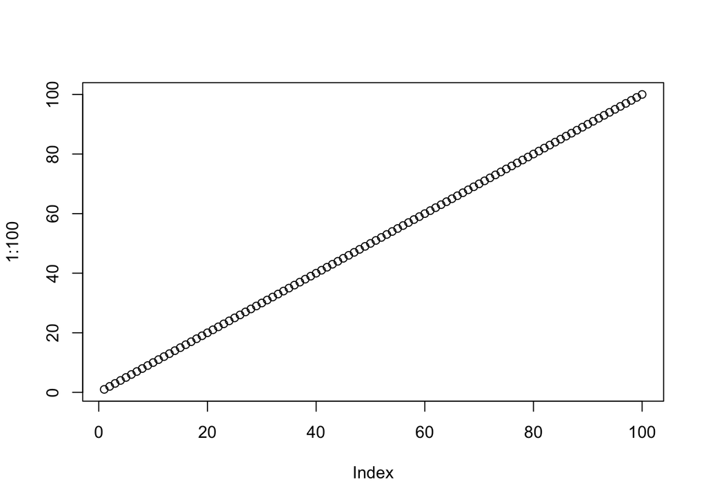

```r
plot(1:100)
```

## R functions

A function, in a programming environment, is a set of instructions. A programmer builds a function to avoid repeating the same task, or reduce complexity.

```r
# Rounding
round(9.1615, 2)
```

```
## [1] 9.16
```

```r
# Square Root
sqrt(9)
```

```
## [1] 3
```

```r
# Sequence function:
# Create a sequence from 10 to 30, add each number by 5
seq.int(10, 30, 5)
```

```
## [1] 10 15 20 25 30
```

## Packages

```r
# Download the package
# install.packages("tidyverse")
# Use the package
# Rember to update packages from time to time
library(tidyverse)
```

```r
# Install more than one package at the same time
# install.packages(c("ggplot2", "palmerpenguins"))
```

## Objects

A name that you can use to call up stored data

```r
# Create and call an object
# A name cannot start with a number and no special symbols
# Also avoid caps and space
# Use dash or underscore instead
salary <- c(20, 30, 40, 50, -60)
salary
```

```
## [1]  20  30  40  50 -60
```

## Combine created objects

```r
# Create more objects
age <- c(34, 54, 23, 65, 2)
books <- c(4, 0, 3, 24, 5)
name <- c("Ram", "John", "Ali", "Pretti", "Rani")
place <- c("ny", "ber", "dhl", "tko", "lon")
```

```r
# Create a data object with data.frame()
social <- data.frame(age, books, name, place, salary)
social
```

```
##   age books   name place salary
## 1  34     4    Ram    ny     20
## 2  54     0   John   ber     30
## 3  23     3    Ali   dhl     40
## 4  65    24 Pretti   tko     50
## 5   2     5   Rani   lon    -60
```

```r
# Save the dataset as a csv file
write.csv(social, "temp_folder/social.csv")
```

## Get documentation of packages

```r
?ggplot
```

# Session 2: Dynamic Documents using R Markdown

3 important parts of R Markdown

1. YAML: Another markup language, marked by the three dash, states the titles, author, etc.
2. Code chunk
3. Text

## Styles

### Hash

The hash is for title, and more hash you put, the smaller the heading will be

### Number List

Just put 1. in front of the text, and numbers will automatically transform into order

1. One
2. Two
3. Three

### Bullet Point

Single hash will transform into bullet points

- See
- It
- Works!

### Text styles

- *Single Star for italic text*
- **Double Stars for bold**
- *Triple Stars for italic and bold*
- Dollar sign for equations
- $E=MC^2$
- Double Dollar sign to put it on the left side

$$a=(b+c)/2$$

### Others

Use Latex-Project for more complex markdown formats